# Cluster 2 Model

Ernesto Carrella

April 10, 2018

## Calibrate Cluster 2

Coalescing the data we gathered for WPP712-713, we have enough information to at least pretend to calibrate the model, at least for cluster number 2. We have a faint idea of what the revenue and expenditure per trip is (this is Elle’s data, subject to major revision after the survey is complete) and we know the catch composition from CODRS.

[video not shown]

Now, imagine everybody is a simple explore-exploit-imitate agent and we just want to find catchability and biomass for the 3 major species (multidens, typus and malabaricus). We allocate fish at random following only depth limits as the ones I could find in fishbase. Cluster 2 fishers catch almost exclusively malabaricus (plus smaller species). They primarily fish out of Brondong (8 boats), with a small presence in Balikpapan (2 boats) and Galesong (3) boats.

Calibration plots follow (red dashed line is the “real world” average, blue shades are guessed standard deviations, histograms are simulation outputs):

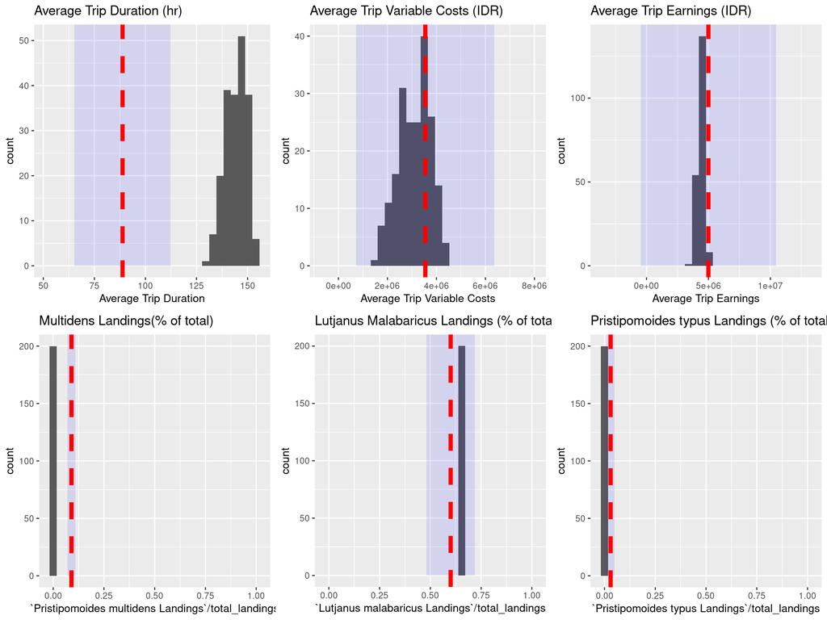

Basically the trips last too long in comparison to reality, earnings and costs are about right as is Malabaricus % but multidens is a bit off as well.

Here’s a comparison between areas fished in a simulation (left) and real fished areas on the right:

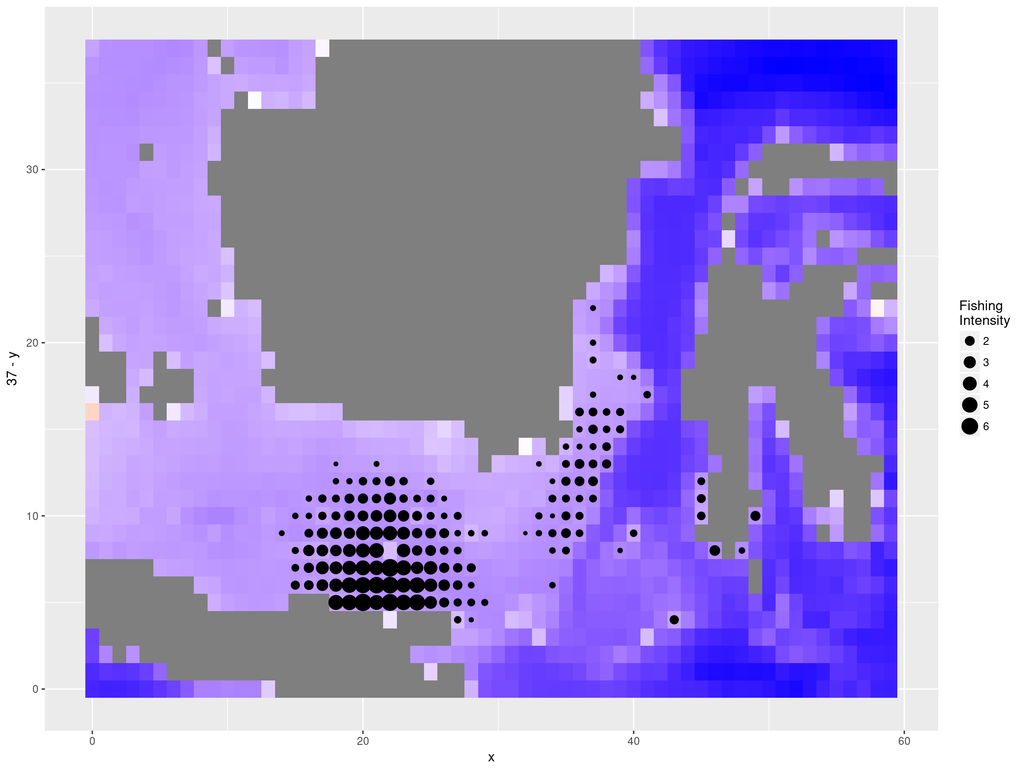

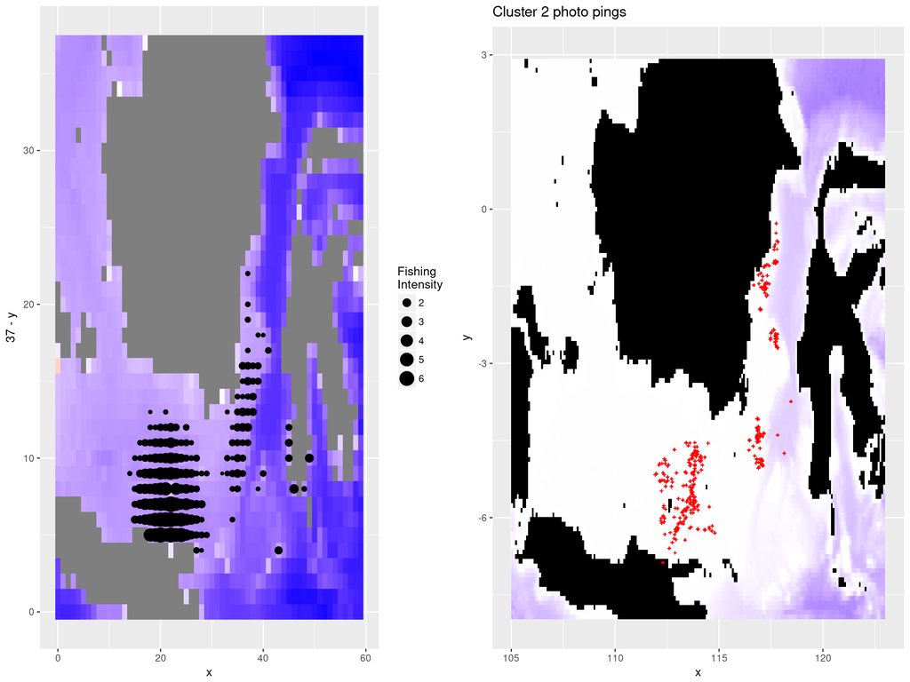

Notice how we tend to get Galesong fishing wrong: in reality they travel west before fishing while in our model they tend to stick to coastal areas close at home. This is probably because our assumption of depth-based distribution of fish is wrong, but we can improve on this by adding geographical aspects to the calibration.